# 2º Script [R] - Análise dos livros mais lidos do Skoob

Lucas Tavares Brito

14/08/2023

## Introdução

Criei esse arquivo em RMarkdown para explicar melhor o meu raciocínio ao longo da execução do código e para deixá-lo mais apresentável para vocês.

A partir do arquivo CSV gerado no 1º Script, fiz algumas das análises com as quais eu estou familiarizado no R. Tentei diversificar os métodos utilizados para mostrar ferramentas diferentes sendo utilizadas em um mesmo projeto (quase todas elas contidas na biblioteca base do R e no tidyverse).

Obs.: Para rodar esse script, basta adicionar o CSV “informacoesLivros_skoob” do 1º Script que enviei para vocês na pasta desse arquivo, ajustar o caminho de referência no segundo bloco de código e rodar o script.

## Limpeza dos dados

Primeiro, vou importar as bibliotecas que usarei para o ambiente de execução.

```r
# Importar bibliotecas necessárias para a operação
library(tidyverse)
library(knitr)
library(scales)
```

Em seguida, alocarei os dados do CSV em um dataframe com o qual trabalharemos. Utilizo a função “glimpse” para ter uma visão geral da base e o que precisa ser modificado.

```r
caminho = "./20230816-225925_informacoesLivros_skoob.csv"

# Converter o arquivo CSV para um dataframe (utilizando utils)
base_livros <- read.csv2(caminho, sep = ",", fileEncoding = "utf8")

# Ver o dataframe e seus tipos de dados (utilizando dplyr)
glimpse(base_livros)
```

```
## Rows: 106
## Columns: 22
## $ id_livro         <int> 693, 108, 247555, 357, 358, 355, 359, 736, 562, 1200,~
## $ titulo           <chr> "O Pequeno Príncipe", "Harry Potter e a Pedra Filosof~
## $ genero           <chr> "Infantil / Ficção / Literatura Estrangeira ", "Avent~
## $ autor            <chr> "Antoine de Saint-Exupéry", "J.K. Rowling ", "John Gr~
## $ local_autor      <chr> "\nFrança \n- Lyon \n", "\nInglaterra \n- Gloucesters~
## $ status_leram     <chr> "789.936", "743.705", "628.527", "628.159", "577.592"~
## $ status_lendo     <chr> "11.597", "19.924", "13.452", "12.004", "9.766", "13.~
## $ status_queremLer <chr> "181.339", "168.110", "277.696", "133.536", "159.002"~
## $ status_relendo   <chr> "2.174", "2.732", "1.190", "1.238", "1.017", "1.078",~
## $ status_abandonos <chr> "3.945", "4.546", "6.549", "2.610", "1.984", "2.920",~
## $ status_resenhas  <chr> "14.515", "15.717", "10.016", "10.005", "9.457", "7.5~
## $ media_avaliacoes <chr> "4.5", "4.5", "4.2", "4.4", "4.7", "4.6", "4.6", "4.4~
## $ num_avaliacoes   <chr> "244.936 avaliações", "281.490 avaliações", "193.045 ~
## $ percent_1estrela <chr> "1%", "0%", "1%", "0%", "0%", "0%", "0%", "0%", "0%",~
## $ percent_2estrela <chr> "2%", "1%", "4%", "1%", "0%", "1%", "1%", "1%", "1%",~
## $ percent_3estrela <chr> "9%", "8%", "15%", "9%", "4%", "6%", "6%", "9%", "5%"~
## $ percent_4estrela <chr> "21%", "24%", "29%", "26%", "16%", "21%", "21%", "27%~
## $ percent_5estrela <chr> "67%", "67%", "51%", "63%", "78%", "72%", "71%", "62%~
## $ percent_masc     <chr> " 16%", " 21%", " 10%", " 21%", " 21%", " 21%", " 21%~
## $ percent_femi     <chr> " 84% ", " 79% ", " 90% ", " 79% ", " 79% ", " 79% ",~
## $ tags_populares   <chr> "literatura infanto-juvenil, filosofia, aventura, clá~
## $ link_resenhas    <chr> "https://www.skoob.com.br/livro/resenhas/693/edicao:5~
```

O primeiro passo para realizar a análise dos dados é a limpeza da base.

Começarei pela coluna “genero”. Nela, há todos os gêneros nos quais um livro se enquadra. Essa classificação é feita através de strings que seguem o formato “Genero Primário / Gênero Secundário / Gênero Terciário…”. Podemos quebrar essa coluna em categorias separadas, para melhor observação.

```r
# Separar a coluna "genero" em 8 outras colunas (utilizando tidyr)
base_livros <- separate(base_livros, genero, into = c("genero1", "genero2", "genero3", "genero4", "genero5", "genero6", "genero7", "genero8"), sep = " / ")

# Exibir base ajustada (utilizando knitr)
kable(head(base_livros[, 1:10]), caption = "Livros e seus gêneros")
```

Livros e seus gêneros

| id_livro | titulo | genero1 | genero2 | genero3 | genero4 | genero5 | genero6 | genero7 | genero8 |
| --- | --- | --- | --- | --- | --- | --- | --- | --- | --- |
| 693 | O Pequeno Príncipe | Infantil | Ficção | Literatura Estrangeira | NA | NA | NA | NA | NA |
| 108 | Harry Potter e a Pedra Filosofal | Aventura | Fantasia | Literatura Estrangeira | Ficção | Infantojuvenil | NA | NA | NA |
| 247555 | A Culpa é das Estrelas | Literatura Estrangeira | Romance | NA | NA | NA | NA | NA | NA |
| 357 | Harry Potter e a Câmara Secreta | Aventura | Fantasia | Ficção | Literatura Estrangeira | Infantojuvenil | NA | NA | NA |
| 358 | Harry Potter e o Prisioneiro de Azkaban | Aventura | Fantasia | Literatura Estrangeira | Ficção | Infantojuvenil | NA | NA | NA |
| 355 | Harry Potter e o Cálice de Fogo | Aventura | Fantasia | Ficção | Infantojuvenil | Jovem adulto | Literatura Estrangeira | Romance | NA |

Agora, vamos para a coluna “local_autor”: nela, há as informações de país, estado e cidade de nascimento do autor de cada livro. Para as nossas análises, só o país é relevante, então modificaremos as strings para que elas contenham apenas essa informação, possibilitando agrupar as observações em categorias maiores.

```r
# Pegar apenas os países da coluna "local_autor" (utilizando stringr)
delimitador = ' \n'

base_livros$local_autor <- str_extract(base_livros$local_autor, paste0(".*(?=", delimitador, ")"))

# Vamos também eliminar os diferentes nomes da coluna "local_autor"
base_livros[base_livros$local_autor == "Estados Unidos da América", "local_autor"] <- "Estados Unidos"
base_livros[base_livros$local_autor == "EUA", "local_autor"] <- "Estados Unidos"
base_livros[base_livros$local_autor == "Califórnia", "local_autor"] <- "Estados Unidos"

base_livros[base_livros$local_autor == "Inglaterra", "local_autor"] <- "Reino Unido"
base_livros[base_livros$local_autor == "Grã-Bretanha", "local_autor"] <- "Reino Unido"

# Exibir base ajustada (utilizando knitr)
kable(head(base_livros$local_autor), caption = "País de nascimento dos autores")
```

País de nascimento dos autores

| x |
| --- |
| França |
| Reino Unido |
| Estados Unidos |
| Reino Unido |
| Reino Unido |
| Reino Unido |

Outra possibilidade de tratamento é identificada: vemos que algumas variáveis dessa base não podem ser utilizadas por serem do tipo “chr”. Vamos convertê-las para o tipo “dbl”, com o qual podemos fazer operações matemáticas.

```r
# Substituir os símbolos de porcento de todos os elementos das colunas 21 a 27 (utilizando dplyr e pipe)
base_livros[, 21:27] <- base_livros[, 21:27] %>%
  mutate_all(list(~str_replace(., '%', '')))

# Retirar todos os pontos dos números (utilizando dplyr e pipe)
base_livros[, c(13:18, 20)] <- base_livros[, c(13:18, 20)] %>%
  mutate_all(list(~str_replace(., '\\.', '')))

# Remover string "avaliações" do final de todos os elementos da coluna "num_avaliacoes"
base_livros$num_avaliacoes <- gsub('.{11}$', '', base_livros$num_avaliacoes)

# Agora, só precisamos transformar todas as colunas modificadas em variáveis numéricas
base_livros[, 13:27] <- sapply(base_livros[, 13:27], as.numeric)

glimpse(base_livros[, 13:27])
```

```
## Rows: 106
## Columns: 15
## $ status_leram     <dbl> 789936, 743705, 628527, 628159, 577592, 529683, 48714~
## $ status_lendo     <dbl> 11597, 19924, 13452, 12004, 9766, 13337, 10673, 13597~
## $ status_queremLer <dbl> 181339, 168110, 277696, 133536, 159002, 197709, 21028~
## $ status_relendo   <dbl> 2174, 2732, 1190, 1238, 1017, 1078, 943, 1624, 735, 8~
## $ status_abandonos <dbl> 3945, 4546, 6549, 2610, 1984, 2920, 2447, 3710, 1268,~
## $ status_resenhas  <dbl> 14515, 15717, 10016, 10005, 9457, 7522, 6610, 12072, ~
## $ media_avaliacoes <dbl> 4.5, 4.5, 4.2, 4.4, 4.7, 4.6, 4.6, 4.4, 4.6, 4.7, 4.3~
## $ num_avaliacoes   <dbl> 244936, 281490, 193045, 228241, 205455, 180004, 16327~
## $ percent_1estrela <dbl> 1, 0, 1, 0, 0, 0, 0, 0, 0, 0, 1, 1, 5, 1, 0, 6, 1, 0,~
## $ percent_2estrela <dbl> 2, 1, 4, 1, 0, 1, 1, 1, 1, 0, 2, 2, 9, 4, 2, 12, 2, 1~
## $ percent_3estrela <dbl> 9, 8, 15, 9, 4, 6, 6, 9, 5, 3, 12, 8, 22, 18, 13, 26,~
## $ percent_4estrela <dbl> 21, 24, 29, 26, 16, 21, 21, 27, 19, 14, 29, 22, 25, 3~
## $ percent_5estrela <dbl> 67, 67, 51, 63, 78, 72, 71, 62, 76, 82, 57, 67, 39, 4~
## $ percent_masc     <dbl> 16, 21, 10, 21, 21, 21, 21, 22, 21, 21, 3, 14, 10, 3,~
## $ percent_femi     <dbl> 84, 79, 90, 79, 79, 79, 79, 78, 79, 79, 97, 86, 90, 9~
```

Por fim, removeremos as últimas duas colunas dos dados. Elas seria utilizadas em outro projeto, mas não serão necessárias aqui.

```r
base_livros <- base_livros[, -28:-29]
```

Assim ficou a versão final do dataframe, inteiramente tratado:

```r
# Exibir base ajustada (utilizando knitr)
kable(head(base_livros), caption = "Dataframe final")
```

Dataframe final

| id_livro | titulo | genero1 | genero2 | genero3 | genero4 | genero5 | genero6 | genero7 | genero8 | autor | local_autor | status_leram | status_lendo | status_queremLer | status_relendo | status_abandonos | status_resenhas | media_avaliacoes | num_avaliacoes | percent_1estrela | percent_2estrela | percent_3estrela | percent_4estrela | percent_5estrela | percent_masc | percent_femi |
| --- | --- | --- | --- | --- | --- | --- | --- | --- | --- | --- | --- | --- | --- | --- | --- | --- | --- | --- | --- | --- | --- | --- | --- | --- | --- | --- |
| 693 | O Pequeno Príncipe | Infantil | Ficção | Literatura Estrangeira | NA | NA | NA | NA | NA | Antoine de Saint-Exupéry | França | 789936 | 11597 | 181339 | 2174 | 3945 | 14515 | 4.5 | 244936 | 1 | 2 | 9 | 21 | 67 | 16 | 84 |
| 108 | Harry Potter e a Pedra Filosofal | Aventura | Fantasia | Literatura Estrangeira | Ficção | Infantojuvenil | NA | NA | NA | J.K. Rowling | Reino Unido | 743705 | 19924 | 168110 | 2732 | 4546 | 15717 | 4.5 | 281490 | 0 | 1 | 8 | 24 | 67 | 21 | 79 |
| 247555 | A Culpa é das Estrelas | Literatura Estrangeira | Romance | NA | NA | NA | NA | NA | NA | John Green | Estados Unidos | 628527 | 13452 | 277696 | 1190 | 6549 | 10016 | 4.2 | 193045 | 1 | 4 | 15 | 29 | 51 | 10 | 90 |
| 357 | Harry Potter e a Câmara Secreta | Aventura | Fantasia | Ficção | Literatura Estrangeira | Infantojuvenil | NA | NA | NA | J.K. Rowling | Reino Unido | 628159 | 12004 | 133536 | 1238 | 2610 | 10005 | 4.4 | 228241 | 0 | 1 | 9 | 26 | 63 | 21 | 79 |
| 358 | Harry Potter e o Prisioneiro de Azkaban | Aventura | Fantasia | Literatura Estrangeira | Ficção | Infantojuvenil | NA | NA | NA | J.K. Rowling | Reino Unido | 577592 | 9766 | 159002 | 1017 | 1984 | 9457 | 4.7 | 205455 | 0 | 0 | 4 | 16 | 78 | 21 | 79 |
| 355 | Harry Potter e o Cálice de Fogo | Aventura | Fantasia | Ficção | Infantojuvenil | Jovem adulto | Literatura Estrangeira | Romance | NA | J.K. Rowling | Reino Unido | 529683 | 13337 | 197709 | 1078 | 2920 | 7522 | 4.6 | 180004 | 0 | 1 | 6 | 21 | 72 | 21 | 79 |

## Visualização dos dados

Por fim, apresento 5 visualizações dos dados tratados nesse script. Foquei nas análises mais relevantes dos dados, que permitissem imagens mais interessantes e que utilizassem mais recursos da biblioteca “ggplot2”.

Obs.: Nas visualizações onde são apresentadas regressões, coloco conjuntamente os coeficientes da referida regressão, para referência.

### 1ª Visualização: Gráfico de barras - Número de leituras vs. País de origem do autor

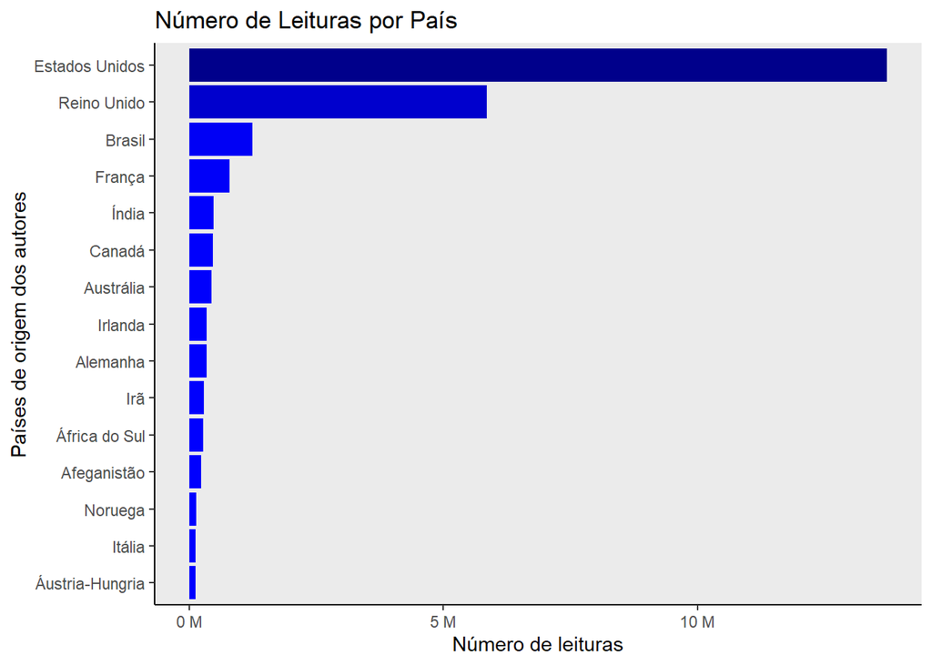

```r
# Criar dataframe-resumo, com o somatório de leituras por país (utilizando dplyr e pipe)
a <- base_livros %>%
  group_by(local_autor) %>%
  summarise(sum(status_leram))

# Alterar nome das colunas
colnames(a) <- c("local_autor", "status_leram")

# Montar gráfico (utilizando ggplot2)
ggplot(a, aes(x = reorder(local_autor, status_leram), y = status_leram, fill = status_leram))+
  geom_bar(stat="identity") +
  coord_flip() +
  scale_fill_gradient(low="blue",high="darkblue") +
  labs(title = "Número de Leituras por País", x = "Países de origem dos autores", y = "Número de leituras") +
  scale_y_continuous(labels = unit_format(unit = "M", scale = 1e-6)) +
  theme(panel.border = element_blank(), panel.grid.major = element_blank(),
panel.grid.minor = element_blank(), axis.line = element_line(colour = "black"), legend.position = "none")
```

### 2ª Visualização: Histograma - Média das avaliações

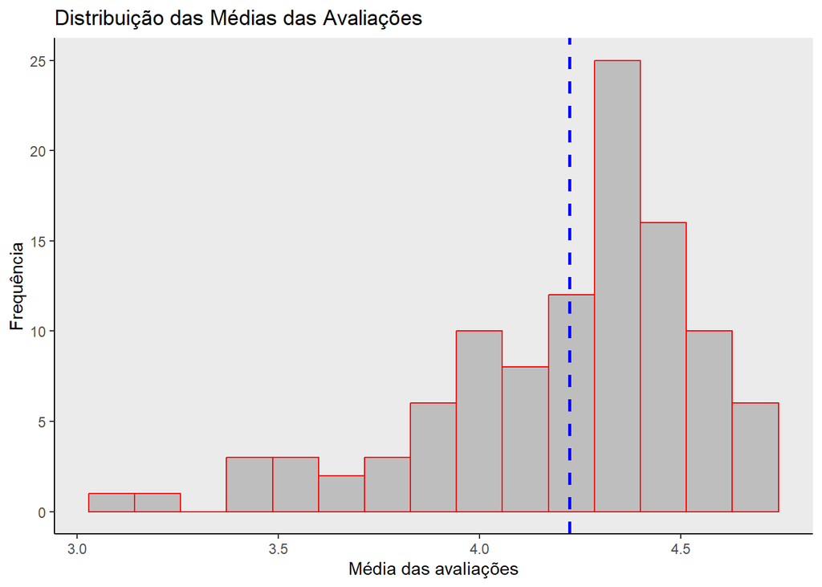

```r
# Montar gráfico (utilizando ggplot2)
ggplot(base_livros, aes(x = media_avaliacoes)) +
  geom_histogram(colour = "red", fill = "grey", bins = 15) +
  geom_vline(aes(xintercept=mean(media_avaliacoes)),
            color="blue", linetype="dashed", size=1) +
  labs(title = "Distribuição das Médias das Avaliações", x = "Média das avaliações", y = "Frequência") +
  theme(panel.border = element_blank(), panel.grid.major = element_blank(),
panel.grid.minor = element_blank(), axis.line = element_line(colour = "black"))
```

### 3ª Visualização: Gráfico de dispersão - Médias das avaliações vs. Número de leituras vs. Gênero do livro

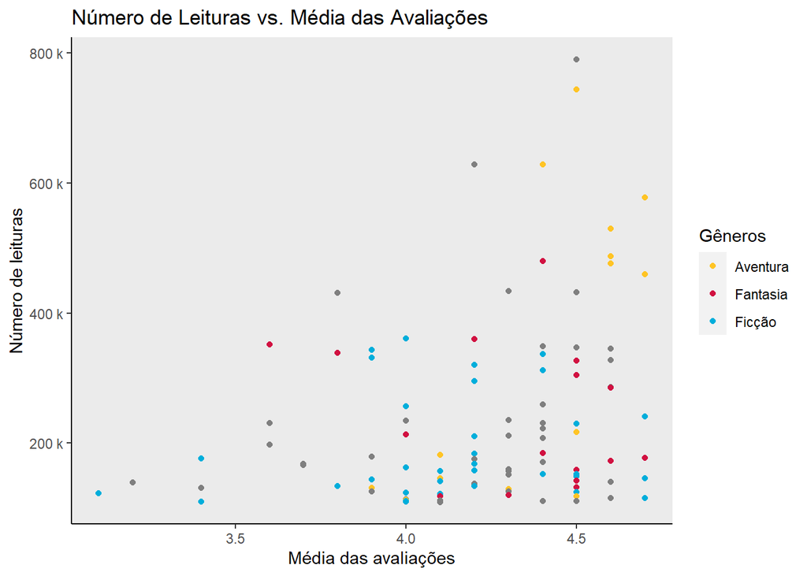

```r
ggplot(base_livros, aes(x = media_avaliacoes, y = status_leram, color = genero1)) +
  geom_point() +
  scale_y_continuous(labels = unit_format(unit = "k", scale = 1e-3)) +
  labs(title = "Número de Leituras vs. Média das Avaliações", x = "Média das avaliações", y = "Número de leituras", color = "Gêneros") +
  scale_color_manual(values = c("Aventura" = "#ffc425", "Ficção" = "#00aedb", "Fantasia" = "#d11141")) +
  theme(panel.border = element_blank(), panel.grid.major = element_blank(),
panel.grid.minor = element_blank(), axis.line = element_line(colour = "black"))
```

### 4ª Visualização: Gráfico de Dispersão - Média das avaliações vs. Número de resenhas

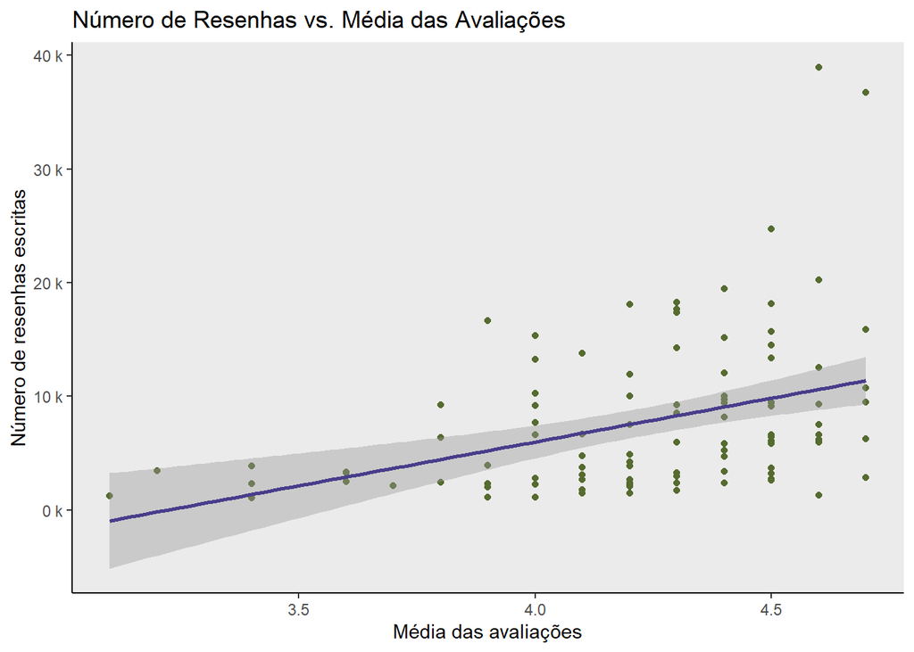

```r
ggplot(base_livros, aes(x = media_avaliacoes, y = status_resenhas)) +
  geom_point(colour = "darkolivegreen") +
  geom_smooth(method = lm, colour = "darkslateblue") +
  scale_y_continuous(labels = unit_format(unit = "k", scale = 1e-3)) +
  labs(title = "Número de Resenhas vs. Média das Avaliações", x = "Média das avaliações", y = "Número de resenhas escritas") +
  theme(panel.border = element_blank(), panel.grid.major = element_blank(),
panel.grid.minor = element_blank(), axis.line = element_line(colour = "black"))
```

Regressão linear simples

- Variável explicada: Número de resenhas
- Variável explicativa: Média das avaliações

```r
summary(lm(base_livros$status_resenhas ~ base_livros$media_avaliacoes))
```

```
##
## Call:
## lm(formula = base_livros$status_resenhas ~ base_livros$media_avaliacoes)
##
## Residuals:
##    Min     1Q Median     3Q    Max
##  -9328  -4118  -1416   2514  28343
##
## Coefficients:
##                              Estimate Std. Error t value Pr(>|t|)
## (Intercept)                    -24835       7613  -3.262   0.0015 **
## base_livros$media_avaliacoes     7707       1797   4.290 4.02e-05 ***
## ---
## Signif. codes:  0 '***' 0.001 '**' 0.01 '*' 0.05 '.' 0.1 ' ' 1
##
## Residual standard error: 6309 on 104 degrees of freedom
## Multiple R-squared:  0.1503, Adjusted R-squared:  0.1422
## F-statistic:  18.4 on 1 and 104 DF,  p-value: 4.018e-05
```

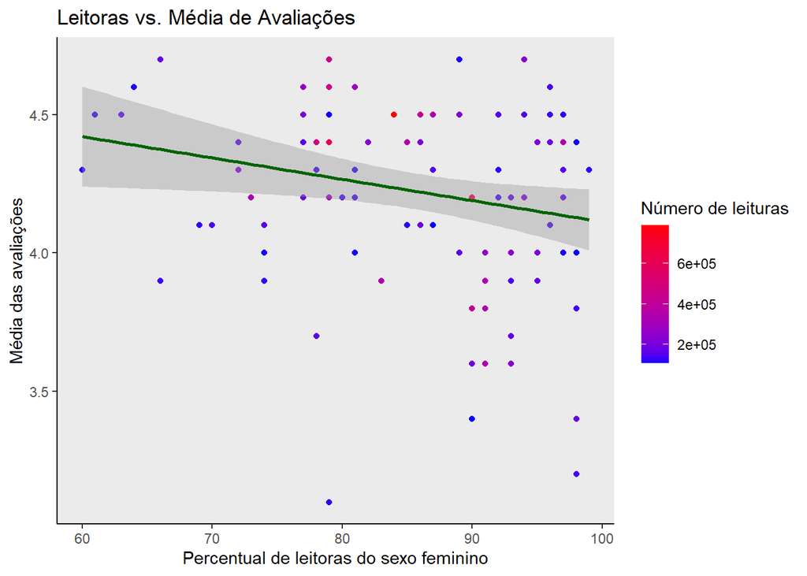

```r
ggplot(base_livros, aes(x = percent_femi, y = media_avaliacoes, color = status_leram)) +
  geom_point() +
  labs(title = "Leitoras vs. Média de Avaliações", x = "Percentual de leitoras do sexo feminino", y = "Média das avaliações", color = "Número de leituras") +
  theme(panel.border = element_blank(), panel.grid.major = element_blank(),
panel.grid.minor = element_blank(), axis.line = element_line(colour = "black")) +
  scale_color_gradient(low="blue", high="red") +
  geom_smooth(method = lm, color = "darkgreen")
```

Regressão linear simples

- Variável explicada: Média das avaliações
- Variável explicativa: Percentual de leitoras do sexo feminino

```r
summary(lm(base_livros$media_avaliacoes ~ base_livros$percent_femi))
```

```
##
## Call:
## lm(formula = base_livros$media_avaliacoes ~ base_livros$percent_femi)
##
## Residuals:
##      Min       1Q   Median       3Q      Max
## -1.17441 -0.16265  0.06798  0.25469  0.54120
##
## Coefficients:
##                           Estimate Std. Error t value Pr(>|t|)
## (Intercept)               4.883277   0.287435   16.99   <2e-16 ***
## base_livros$percent_femi -0.007707   0.003336   -2.31   0.0229 *
## ---
## Signif. codes:  0 '***' 0.001 '**' 0.01 '*' 0.05 '.' 0.1 ' ' 1
##
## Residual standard error: 0.3358 on 104 degrees of freedom
## Multiple R-squared:  0.04881,    Adjusted R-squared:  0.03966
## F-statistic: 5.336 on 1 and 104 DF,  p-value: 0.02286
```

## Conclusão

Espero que esses dois scripts atendam à demanda de vocês. Em caso de dúvidas, estou à disposição.

Aguardo ansiosamente o feedback e espero podermos trabalhar juntos no futuro.

Cordialmente,

Lucas Brito.